# Usando Regressão Linear para Explicar a votação de Deputados

Juan Barros

26 de setembro de 2018

### 1- Um modelo de regressão múltipla com todas as variáveis é plausível para explicar a variação em y (número de votos) em 2006? Mesma pergunta para 2010.

Não. Os dados contidos nessas bases de dados não são totalmente quantitativos, ou seja, é possível encontrar dados que representam categorias e devem se utilizar de outras estratégias de análise. Desconsiderando estes dados, temos os seguintes modelos:

```r
regressaoTotal2006 <- lm(votos ~ media_despesa + total_despesa + quantidade_fornecedores + quantidade_despesas + recursos_de_partido_politico + recursos_proprios + recursos_de_pessoas_juridicas + recursos_de_pessoas_fisicas + recursos_de_outros_candidatos.comites + media_receita + total_receita + quantidade_doadores + quantidade_doacoes, dados2006)

regressaoTotal2010 <- lm(votos ~ media_despesa + total_despesa + quantidade_fornecedores + quantidade_despesas + recursos_de_partido_politico + recursos_proprios + recursos_de_pessoas_juridicas + recursos_de_pessoas_fisicas + recursos_de_outros_candidatos.comites + media_receita + total_receita + quantidade_doadores + quantidade_doacoes, dados2010)
```

No modelo de 2006, temos os seguintes valores obtidos:

```r
summary(regressaoTotal2006)
```

```
##
## Call:
## lm(formula = votos ~ media_despesa + total_despesa + quantidade_fornecedores +
##     quantidade_despesas + recursos_de_partido_politico + recursos_proprios +
##     recursos_de_pessoas_juridicas + recursos_de_pessoas_fisicas +
##     recursos_de_outros_candidatos.comites + media_receita + total_receita +
##     quantidade_doadores + quantidade_doacoes, data = dados2006)
##
## Residuals:
##     Min      1Q  Median      3Q     Max
## -230946   -7027   -4513    -755  640474
##
## Coefficients: (1 not defined because of singularities)
##                                         Estimate Std. Error t value
## (Intercept)                           3849.23177  711.29486   5.412
## media_despesa                            0.85615    0.41968   2.040
## total_despesa                            0.13696    0.01305  10.497
## quantidade_fornecedores                 -2.55591   12.98837  -0.197
## quantidade_despesas                    -24.82152    9.77795  -2.539
## recursos_de_partido_politico            -0.10614    0.02189  -4.849
## recursos_proprios                       -0.09449    0.01309  -7.220
## recursos_de_pessoas_juridicas           -0.03102    0.01156  -2.684
## recursos_de_pessoas_fisicas              0.05666    0.01791   3.164
## recursos_de_outros_candidatos.comites   -0.06493    0.01924  -3.374
## media_receita                            1.21160    0.10431  11.616
## total_receita                                 NA         NA      NA
## quantidade_doadores                    348.53029  134.28877   2.595
## quantidade_doacoes                     -78.17668  124.32531  -0.629
##                                       Pr(>|t|)
## (Intercept)                           6.68e-08 ***
## media_despesa                          0.04143 *
## total_despesa                          < 2e-16 ***
## quantidade_fornecedores                0.84401
## quantidade_despesas                    0.01118 *
## recursos_de_partido_politico          1.30e-06 ***
## recursos_proprios                     6.39e-13 ***
## recursos_de_pessoas_juridicas          0.00730 **
## recursos_de_pessoas_fisicas            0.00157 **
## recursos_de_outros_candidatos.comites  0.00075 ***
## media_receita                          < 2e-16 ***
## total_receita                               NA
## quantidade_doadores                    0.00949 **
## quantidade_doacoes                     0.52952
## ---
## Signif. codes:  0 '***' 0.001 '**' 0.01 '*' 0.05 '.' 0.1 ' ' 1
##
## Residual standard error: 31650 on 3423 degrees of freedom
## Multiple R-squared:  0.5173, Adjusted R-squared:  0.5156
## F-statistic: 305.7 on 12 and 3423 DF,  p-value: < 2.2e-16
```

Podemos verificar que a maior parte dos parâmetros considerados para a geração do modelo tem um p-valor baixo, representando um bom nível descritivo. Contudo, a medida de qualidade de ajuste do modelo (Multiple R-Squared), indica uma alta quantidade na soma dos resíduos amostrais, podendo concluir que o modelo contém muitos pontos não representados por ele, assertivamente.

Em relação ao ano de 2010, temos o seguinte resultado:

```r
summary(regressaoTotal2010)
```

```
##
## Call:
## lm(formula = votos ~ media_despesa + total_despesa + quantidade_fornecedores +
##     quantidade_despesas + recursos_de_partido_politico + recursos_proprios +
##     recursos_de_pessoas_juridicas + recursos_de_pessoas_fisicas +
##     recursos_de_outros_candidatos.comites + media_receita + total_receita +
##     quantidade_doadores + quantidade_doacoes, data = dados2010)
##
## Residuals:
##     Min      1Q  Median      3Q     Max
## -219059   -8141   -7334   -3200 1303891
##
## Coefficients:
##                                         Estimate Std. Error t value
## (Intercept)                           8282.80811  657.72253  12.593
## media_despesa                            0.14208    0.09006   1.578
## total_despesa                            0.08842    0.01002   8.822
## quantidade_fornecedores                -32.09011   11.17686  -2.871
## quantidade_despesas                     14.51257    9.15901   1.585
## recursos_de_partido_politico            30.30308   83.90777   0.361
## recursos_proprios                       30.27256   83.90775   0.361
## recursos_de_pessoas_juridicas           30.29902   83.90776   0.361
## recursos_de_pessoas_fisicas             30.35243   83.90771   0.362
## recursos_de_outros_candidatos.comites   30.30838   83.90778   0.361
## media_receita                           -0.17835    0.05414  -3.295
## total_receita                          -30.31259   83.90779  -0.361
## quantidade_doadores                    -19.38656   63.05831  -0.307
## quantidade_doacoes                      36.10996   54.37609   0.664
##                                       Pr(>|t|)
## (Intercept)                            < 2e-16 ***
## media_despesa                         0.114740
## total_despesa                          < 2e-16 ***
## quantidade_fornecedores               0.004112 **
## quantidade_despesas                   0.113155
## recursos_de_partido_politico          0.718008
## recursos_proprios                     0.718280
## recursos_de_pessoas_juridicas         0.718044
## recursos_de_pessoas_fisicas           0.717568
## recursos_de_outros_candidatos.comites 0.717961
## media_receita                         0.000994 ***
## total_receita                         0.717924
## quantidade_doadores                   0.758525
## quantidade_doacoes                    0.506678
## ---
## Signif. codes:  0 '***' 0.001 '**' 0.01 '*' 0.05 '.' 0.1 ' ' 1
##
## Residual standard error: 37330 on 4026 degrees of freedom
## Multiple R-squared:  0.4345, Adjusted R-squared:  0.4327
## F-statistic: 237.9 on 13 and 4026 DF,  p-value: < 2.2e-16
```

No segundo caso, o modelo tem o seu p-valor elevado em quase todos os parâmetros. Isso, por si só, já nos indica que esse modelo é problemático. Por fim, o R-Quadrado desse modelo cai e consegue representar menos casos que o anterior.

### 2- Compare as regressões construídas para 2006 e 2010. Quais as diferenças/semelhanças percebidas?

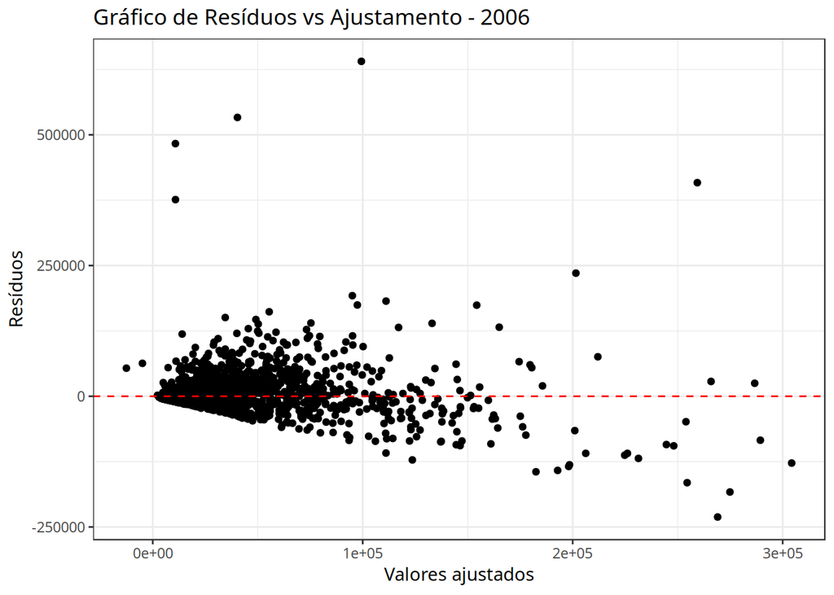

```r
require(ggplot2)
p1 = ggplot(regressaoTotal2006, aes(.fitted, .resid)) +
    geom_point()
p1 = p1 + geom_hline(yintercept=0, col="red", linetype="dashed")
p1 = p1 + xlab("Valores ajustados") + ylab("Resíduos")
p1 = p1 + ggtitle("Gráfico de Resíduos vs Ajustamento - 2006") +
    theme_bw()
p1
```

Com o gráfico acima, fica claro perceber que os erros não estão distribuidos uniformemente, tendo regiões que aglomeram uma quantidade muito alta de pontos. Além disso, a olho nú é possível notar um pequeno padrão na área inferior ao 0 que respeita a forma de uma reta. Isso pode ter acontecido pois os parâmetros passados tenham ligação entre si.

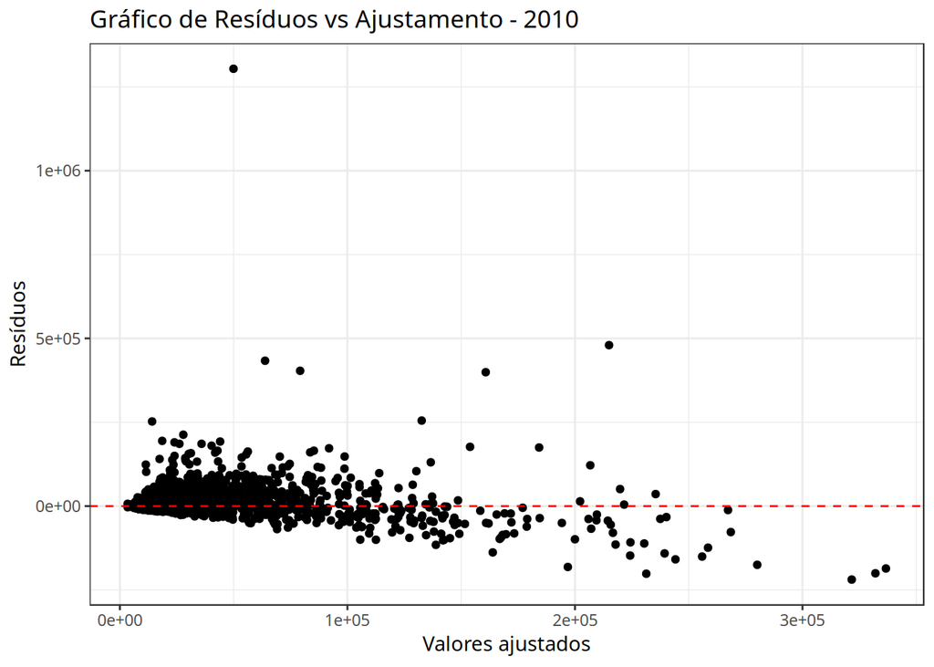

```r
p1 = ggplot(regressaoTotal2010, aes(.fitted, .resid)) +
    geom_point()
p1 = p1 + geom_hline(yintercept=0, col="red", linetype="dashed")
p1 = p1 + xlab("Valores ajustados") + ylab("Resíduos")
p1 = p1 + ggtitle("Gráfico de Resíduos vs Ajustamento - 2010") +
    theme_bw()
p1
```

Em 2010, é possível notar que em geral os pontos são localizados no início, não obedecendo a aleatoriedade esperada em um bom modelo de regressão, além de não parecer simétrica a uma avaliação rápida.

Dessa forma, podemos afirmar que os dois modelos apresentam dispersão de resíduos parecidas, contudo, não recomendadas para modelos representativos de regressão linear.

No modelo de 2006, as variáveis que mais explicam o modelo, tendo em vista o sumário gerado na questão 1, são: Total de despesas, Média da receita e os recursos próprios. Já em 2010, as variáveis são: total de despesa e média da receita. Para o total de despesas e média de receitas, apresentam valores baixos nas duas, contudo na primeira é bem menor a média das receitas. Os recursos próprios em 2006 ajudavam a explicar os dados, mas em 2010 essa variável teve um baixo nível descritivo.

### 3- Todas as variáveis são úteis para os modelos de regressão? Há variáveis redudantes? Faça análises para 2006 e 2010 separadamente.

Com os resultados do sumário, já podemos remover algumas variáveis pouco representativas para nosso modelo. Mas precisamos verificar também, se as variáveis são explicadas por outras. Para isso, utilizarei a matriz de correlação, que mostra o nível de ligação entre os valores das variáveis:

```r
matriz2006 <-
  dados2006 %>%
  select(-ano, -sequencial_candidato, -nome, -uf, -partido, -cargo, -sexo, -grau, -estado_civil, -ocupacao)

cor(matriz2006)
```

```
##                                       quantidade_doacoes
## quantidade_doacoes                            1.00000000
## quantidade_doadores                           0.99521196
## total_receita                                 0.47458771
## media_receita                                 0.04622161
## recursos_de_outros_candidatos.comites         0.18488994
## recursos_de_pessoas_fisicas                   0.49213698
## recursos_de_pessoas_juridicas                 0.40750327
## recursos_proprios                             0.11890417
## recursos_de_partido_politico                  0.22775020
## quantidade_despesas                           0.45721822
## quantidade_fornecedores                       0.44321642
## total_despesa                                 0.50117788
## media_despesa                                 0.07340888
## votos                                         0.46511493
##                                       quantidade_doadores total_receita
## quantidade_doacoes                             0.99521196     0.4745877
## quantidade_doadores                            1.00000000     0.4725823
## total_receita                                  0.47258233     1.0000000
## media_receita                                  0.04375672     0.6751025
## recursos_de_outros_candidatos.comites          0.17880641     0.3630286
## recursos_de_pessoas_fisicas                    0.49334374     0.5175050
## recursos_de_pessoas_juridicas                  0.40921908     0.9040771
## recursos_proprios                              0.10910190     0.5012227
## recursos_de_partido_politico                   0.23301740     0.3191552
## quantidade_despesas                            0.45447902     0.7529272
## quantidade_fornecedores                        0.43964932     0.7771464
## total_despesa                                  0.50033152     0.9824127
## media_despesa                                  0.07582065     0.3070262
## votos                                          0.46797040     0.6353907
##                                       media_receita
## quantidade_doacoes                       0.04622161
## quantidade_doadores                      0.04375672
## total_receita                            0.67510252
## media_receita                            1.00000000
## recursos_de_outros_candidatos.comites    0.23975757
## recursos_de_pessoas_fisicas              0.26424424
## recursos_de_pessoas_juridicas            0.56489005
## recursos_proprios                        0.49315312
## recursos_de_partido_politico             0.18786081
```

[output cut: 125 more lines]

```
##                                           votos
## quantidade_doacoes                    0.4651149
## quantidade_doadores                   0.4679704
## total_receita                         0.6353907
## media_receita                         0.4795471
## recursos_de_outros_candidatos.comites 0.2431073
## recursos_de_pessoas_fisicas           0.4395297
## recursos_de_pessoas_juridicas         0.5928924
## recursos_proprios                     0.2073596
## recursos_de_partido_politico          0.2233023
## quantidade_despesas                   0.4187862
## quantidade_fornecedores               0.4307818
## total_despesa                         0.6577565
## media_despesa                         0.3218516
## votos                                 1.0000000
```

Em 2006, é possível notar que existem algumas variáveis que se correlacionam e acabam afetando o modelo. Podemos citar quantidade de doadores e a quantidade de doação, total da receita e total da despesa, quantidade de fornecedores e quantidade de despesas e recursos de pessoas jurídicas e total de receita.

```r
matriz2010 <-
  dados2010 %>%
  select(-ano, -sequencial_candidato, -nome, -uf, -partido, -cargo, -sexo, -grau, -estado_civil, -ocupacao)

cor(matriz2010)
```

```
##                                       quantidade_doacoes
## quantidade_doacoes                           1.000000000
## quantidade_doadores                          0.997262218
## total_receita                                0.324580685
## media_receita                                0.005969829
## recursos_de_outros_candidatos.comites        0.165544585
## recursos_de_pessoas_fisicas                  0.334353884
## recursos_de_pessoas_juridicas                0.274171259
## recursos_proprios                            0.058935802
## recursos_de_partido_politico                 0.217762744
## quantidade_despesas                          0.551815044
## quantidade_fornecedores                      0.573195136
## total_despesa                                0.337628597
## media_despesa                               -0.002054634
## votos                                        0.259962872
##                                       quantidade_doadores total_receita
## quantidade_doacoes                            0.997262218    0.32458068
## quantidade_doadores                           1.000000000    0.33138583
## total_receita                                 0.331385831    1.00000000
## media_receita                                 0.005032838    0.53157406
## recursos_de_outros_candidatos.comites         0.158931496    0.46158390
## recursos_de_pessoas_fisicas                   0.350711585    0.54430650
## recursos_de_pessoas_juridicas                 0.283445281    0.84297651
## recursos_proprios                             0.059647072    0.43073171
## recursos_de_partido_politico                  0.220780599    0.66597574
## quantidade_despesas                           0.556189002    0.75654660
## quantidade_fornecedores                       0.579420572    0.74797787
## total_despesa                                 0.345962571    0.98986908
## media_despesa                                -0.002178010    0.09557083
## votos                                         0.265889581    0.62615279
##                                       media_receita
## quantidade_doacoes                      0.005969829
## quantidade_doadores                     0.005032838
## total_receita                           0.531574063
## media_receita                           1.000000000
## recursos_de_outros_candidatos.comites   0.318873231
## recursos_de_pessoas_fisicas             0.147504680
## recursos_de_pessoas_juridicas           0.359964518
## recursos_proprios                       0.287888460
## recursos_de_partido_politico            0.443375441
```

[output cut: 125 more lines]

```
##                                           votos
## quantidade_doacoes                    0.2599629
## quantidade_doadores                   0.2658896
## total_receita                         0.6261528
## media_receita                         0.3011384
## recursos_de_outros_candidatos.comites 0.3377833
## recursos_de_pessoas_fisicas           0.4208241
## recursos_de_pessoas_juridicas         0.5446270
## recursos_proprios                     0.1543726
## recursos_de_partido_politico          0.4374969
## quantidade_despesas                   0.4390284
## quantidade_fornecedores               0.4394416
## total_despesa                         0.6365119
## media_despesa                         0.0715033
## votos                                 1.0000000
```

Já em 2010, as variáveis que se correlacionaram foram: quantidade de doadores e quantidade de doação, recursos de pessoas jurídicas e total de receita, total de despesa e total de receita e quantidade de despesas e quantidade de fornecedores.

### 4- No caso de haver variáveis pouco explicativas e/ou redudantes, construa um novo modelo sem essas variáveis e o compare ao modelo com todas as variáveis (e.g. em termos de R2 e RSE). Faça isso para 2006 e 2010 separadamente.

No ano de 2006, podemos retirar as variáveis que tem o p-valor muito alto, ou seja, aqueles valores que não são significativos na nossa regressão. Voltando ao sumário da questão um, retiraremos as variáveis “quantidade de fornecedores” e “quantidade de doações”. Em 2010, aplicando o mesmo raciocínio, deixaremos apenas as variáveis que tiverem importância para nosso modelo.

```r
novaRegressaoTotal2006 <- lm(votos ~ media_despesa + total_despesa + quantidade_despesas + recursos_de_partido_politico + recursos_proprios + recursos_de_pessoas_juridicas + recursos_de_pessoas_fisicas + recursos_de_outros_candidatos.comites + media_receita + quantidade_doadores, dados2006)

novaRegressaoTotal2010 <- lm(votos ~ total_despesa + quantidade_fornecedores + media_receita, dados2010)
```

Agora teremos os seguintes valores para 2006:

```r
summary(novaRegressaoTotal2006)
```

```
##
## Call:
## lm(formula = votos ~ media_despesa + total_despesa + quantidade_despesas +
##     recursos_de_partido_politico + recursos_proprios + recursos_de_pessoas_juridicas +
##     recursos_de_pessoas_fisicas + recursos_de_outros_candidatos.comites +
##     media_receita + quantidade_doadores, data = dados2006)
##
## Residuals:
##     Min      1Q  Median      3Q     Max
## -231144   -7016   -4503    -725  640708
##
## Coefficients:
##                                         Estimate Std. Error t value
## (Intercept)                           3820.16205  703.63143   5.429
## media_despesa                            0.86864    0.41779   2.079
## total_despesa                            0.13671    0.01279  10.691
## quantidade_despesas                    -26.65054    3.36194  -7.927
## recursos_de_partido_politico            -0.10562    0.02178  -4.849
## recursos_proprios                       -0.09520    0.01304  -7.301
## recursos_de_pessoas_juridicas           -0.03107    0.01153  -2.696
## recursos_de_pessoas_fisicas              0.05715    0.01753   3.260
## recursos_de_outros_candidatos.comites   -0.06577    0.01913  -3.437
## media_receita                            1.21409    0.10409  11.664
## quantidade_doadores                    265.04677   17.57440  15.081
##                                       Pr(>|t|)
## (Intercept)                           6.05e-08 ***
## media_despesa                         0.037679 *
## total_despesa                          < 2e-16 ***
## quantidade_despesas                   3.01e-15 ***
## recursos_de_partido_politico          1.29e-06 ***
## recursos_proprios                     3.53e-13 ***
## recursos_de_pessoas_juridicas         0.007061 **
## recursos_de_pessoas_fisicas           0.001124 **
## recursos_de_outros_candidatos.comites 0.000594 ***
## media_receita                          < 2e-16 ***
## quantidade_doadores                    < 2e-16 ***
## ---
## Signif. codes:  0 '***' 0.001 '**' 0.01 '*' 0.05 '.' 0.1 ' ' 1
##
## Residual standard error: 31640 on 3425 degrees of freedom
## Multiple R-squared:  0.5172, Adjusted R-squared:  0.5158
## F-statistic:   367 on 10 and 3425 DF,  p-value: < 2.2e-16
```

… e em 2010:

```r
summary(novaRegressaoTotal2010)
```

```
##
## Call:
## lm(formula = votos ~ total_despesa + quantidade_fornecedores +
##     media_receita, data = dados2010)
##
## Residuals:
##     Min      1Q  Median      3Q     Max
## -271798   -8969   -8049   -3253 1304743
##
## Coefficients:
##                           Estimate Std. Error t value Pr(>|t|)
## (Intercept)              9.375e+03  6.573e+02  14.264  < 2e-16 ***
## total_despesa            7.724e-02  2.187e-03  35.320  < 2e-16 ***
## quantidade_fornecedores -1.185e+01  2.248e+00  -5.270 1.44e-07 ***
## media_receita           -2.196e-01  4.224e-02  -5.199 2.10e-07 ***
## ---
## Signif. codes:  0 '***' 0.001 '**' 0.01 '*' 0.05 '.' 0.1 ' ' 1
##
## Residual standard error: 38030 on 4036 degrees of freedom
## Multiple R-squared:  0.4116, Adjusted R-squared:  0.4112
## F-statistic: 941.1 on 3 and 4036 DF,  p-value: < 2.2e-16
```

### 5- Construa agora uma regressão considerando os anos 2006 e 2010 em conjunto. Que diferenças/semelhanças você percebe em relação aos modelos individuais por ano? Veja a questão 2 para sugestões que você usar para comparação.

Para os anos de 2006 e 2010 teremos a seguinte regressão:

```r
regressaoTotal20062010 <- lm(votos ~ media_despesa + total_despesa + quantidade_fornecedores + quantidade_despesas + recursos_de_partido_politico + recursos_proprios + recursos_de_pessoas_juridicas + recursos_de_pessoas_fisicas + recursos_de_outros_candidatos.comites + media_receita + total_receita + quantidade_doadores + quantidade_doacoes, dados20062010)

summary(regressaoTotal20062010)
```

```
##
## Call:
## lm(formula = votos ~ media_despesa + total_despesa + quantidade_fornecedores +
##     quantidade_despesas + recursos_de_partido_politico + recursos_proprios +
##     recursos_de_pessoas_juridicas + recursos_de_pessoas_fisicas +
##     recursos_de_outros_candidatos.comites + media_receita + total_receita +
##     quantidade_doadores + quantidade_doacoes, data = dados20062010)
##
## Residuals:
##     Min      1Q  Median      3Q     Max
## -357286   -9302   -8305   -2590 1315939
##
## Coefficients: (1 not defined because of singularities)
##                                         Estimate Std. Error t value
## (Intercept)                            9.358e+03  4.769e+02  19.622
## media_despesa                         -9.222e-02  8.500e-02  -1.085
## total_despesa                          9.764e-02  7.969e-03  12.253
## quantidade_fornecedores               -3.830e+01  8.361e+00  -4.581
## quantidade_despesas                    1.373e+01  6.710e+00   2.046
## recursos_de_partido_politico          -4.505e-02  7.874e-03  -5.721
## recursos_proprios                     -4.811e-02  7.652e-03  -6.288
## recursos_de_pessoas_juridicas         -2.179e-03  7.262e-03  -0.300
## recursos_de_pessoas_fisicas            5.425e-02  1.037e-02   5.230
## recursos_de_outros_candidatos.comites -2.722e-02  8.349e-03  -3.260
## media_receita                          1.657e-01  4.732e-02   3.502
## total_receita                                 NA         NA      NA
## quantidade_doadores                    1.396e+02  5.628e+01   2.481
## quantidade_doacoes                    -8.307e+01  4.877e+01  -1.703
##                                       Pr(>|t|)
## (Intercept)                            < 2e-16 ***
## media_despesa                         0.278028
## total_despesa                          < 2e-16 ***
## quantidade_fornecedores               4.70e-06 ***
## quantidade_despesas                   0.040817 *
## recursos_de_partido_politico          1.10e-08 ***
## recursos_proprios                     3.40e-10 ***
## recursos_de_pessoas_juridicas         0.764146
## recursos_de_pessoas_fisicas           1.74e-07 ***
## recursos_de_outros_candidatos.comites 0.001119 **
## media_receita                         0.000464 ***
## total_receita                               NA
## quantidade_doadores                   0.013131 *
## quantidade_doacoes                    0.088559 .
## ---
## Signif. codes:  0 '***' 0.001 '**' 0.01 '*' 0.05 '.' 0.1 ' ' 1
##
## Residual standard error: 36640 on 7463 degrees of freedom
## Multiple R-squared:  0.4115, Adjusted R-squared:  0.4105
## F-statistic: 434.8 on 12 and 7463 DF,  p-value: < 2.2e-16
```

Podemos perceber que o nível de significancia em cada variável do modelo sofre leve queda em relação a 2006 e considerável aumento se comparado com o modelo de 2010.

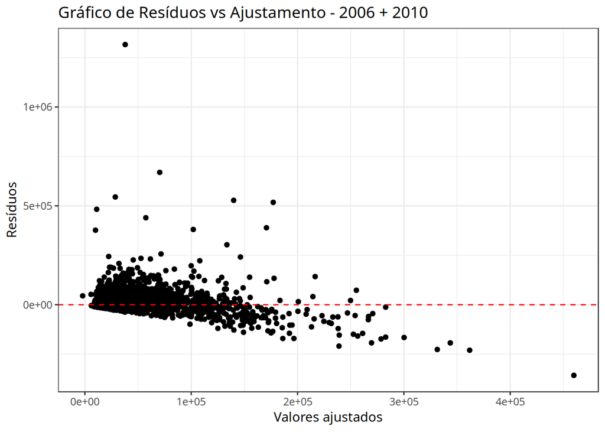

```r
p1 = ggplot(regressaoTotal20062010, aes(.fitted, .resid)) +
    geom_point()
p1 = p1 + geom_hline(yintercept=0, col="red", linetype="dashed")
p1 = p1 + xlab("Valores ajustados") + ylab("Resíduos")
p1 = p1 + ggtitle("Gráfico de Resíduos vs Ajustamento - 2006 + 2010") +
    theme_bw()
p1
```

Já em relação aos resíduos deixados no modelo, a união dos dados dos dois anos não ajuda a melhorar e torna-lo aleatório e simétrico em relação ao eixo horizontal. Os resíduos continuam aglomerados em regiões e ainda parece ter certo padrão na parte inferior inicial.